# Practical Machine Learning: Course Project Prediction Assignment Writeup

Dipankar

14 September 2017

## Executive Summary

By means of devices such as Jawbone Up, Nike FuelBand, and Fitbit it is now possible to assemble a large amount of data about personal activity relatively inexpensively. These type of devices are part of the quantified self movement - a group of enthusiasts who take measurements about themselves regularly to improve their health, to find patterns in their behavior, or because they are tech geeks. In this project, your goal will be to use data from accelerometers on the belt, forearm, arm, and dumbell of 6 participants.

Six young health participants were asked to perform one set of 10 repetitions of the Unilateral Dumbbell Biceps Curl in five different fashions: exactly according to the specification (Class A), throwing the elbows to the front (Class B), lifting the dumbbell only halfway (Class C), lowering the dumbbell only halfway (Class D) and throwing the hips to the front (Class E).

The test and training data as follows :-

The training data for this project are available [here](https://d396qusza40orc.cloudfront.net/predmachlearn/pml-training.csv).

The test data are available [here](https://d396qusza40orc.cloudfront.net/predmachlearn/pml-testing.csv).

### Processing & Cleaning of data

```r
#Environment Preparation
setwd("E:/coussera/Practical Machine Learning/week4/assignment")
library(knitr);library(caret);library(rpart); library(rpart.plot); library(rattle); library(randomForest); library(corrplot);
set.seed(10000)

#Read the Dataset.
# download the datasets
training <- read.csv("pml-training.csv")
testing  <- read.csv("pml-testing.csv")

# create a partition with the training dataset
inTrain  <- createDataPartition(training$classe, p=0.7, list=FALSE)
TrainSet <- training[inTrain, ]
TestSet  <- training[-inTrain, ]

# remove variables with Nearly Zero Variance
NZV <- nearZeroVar(TrainSet)
TrainSet <- TrainSet[, -NZV]
TestSet  <- TestSet[, -NZV]

# remove variables that are mostly NA
AllNA    <- sapply(TrainSet, function(x) mean(is.na(x))) > 0.95
TrainSet <- TrainSet[, AllNA==FALSE]
TestSet  <- TestSet[, AllNA==FALSE]

# remove identification only variables (columns 1 to 5)
TrainSet <- TrainSet[, -(1:5)]
TestSet  <- TestSet[, -(1:5)]
```

### Model Prediction

#### Decision Trees

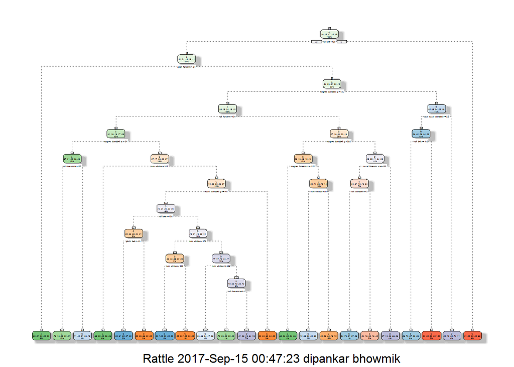

```r
# model-fit
set.seed(10000)
modFitDecTree <- rpart(classe ~ ., data=TrainSet, method="class")
fancyRpartPlot(modFitDecTree)
```

```r
# prediction - Test dataset
predictDecTree <- predict(modFitDecTree, newdata=TestSet, type="class")
confMatDecTree <- confusionMatrix(predictDecTree, TestSet$classe)
confMatDecTree
```

```
## Confusion Matrix and Statistics
##
##           Reference
## Prediction    A    B    C    D    E
##          A 1480  151   18   46   49
##          B  134  759   61  125  151
##          C   17   76  815  150   98
##          D   17   95   70  604  122
##          E   26   58   62   39  662
##
## Overall Statistics
##
##                Accuracy : 0.7341
##                  95% CI : (0.7226, 0.7453)
##     No Information Rate : 0.2845
##     P-Value [Acc > NIR] : < 2.2e-16
##
##                   Kappa : 0.6631
##  Mcnemar's Test P-Value : < 2.2e-16
##
## Statistics by Class:
##
##                      Class: A Class: B Class: C Class: D Class: E
## Sensitivity            0.8841   0.6664   0.7943   0.6266   0.6118
## Specificity            0.9373   0.9008   0.9298   0.9382   0.9615
## Pos Pred Value         0.8486   0.6171   0.7050   0.6652   0.7816
## Neg Pred Value         0.9532   0.9184   0.9554   0.9277   0.9166
## Prevalence             0.2845   0.1935   0.1743   0.1638   0.1839
## Detection Rate         0.2515   0.1290   0.1385   0.1026   0.1125
## Detection Prevalence   0.2963   0.2090   0.1964   0.1543   0.1439
## Balanced Accuracy      0.9107   0.7836   0.8621   0.7824   0.7867
```

The accuracy of decision tree by rpart method is 73.4%, which is quiet low.

#### Boosted Model

```r
# model-fit
set.seed(10000)
controlGBM <- trainControl(method = "repeatedcv", number = 5, repeats = 1)
modFitGBM  <- train(classe ~ ., data=TrainSet, method = "gbm",
                    trControl = controlGBM, verbose = FALSE)
modFitGBM$finalModel
```

```
## A gradient boosted model with multinomial loss function.
## 150 iterations were performed.
## There were 53 predictors of which 47 had non-zero influence.
```

```r
# prediction - dataset
predictGBM <- predict(modFitGBM, newdata=TestSet)
confMatGBM <- confusionMatrix(predictGBM, TestSet$classe)
confMatGBM
```

```
## Confusion Matrix and Statistics
##
##           Reference
## Prediction    A    B    C    D    E
##          A 1673    5    0    0    0
##          B    1 1122   20    0    2
##          C    0   11 1005   18    1
##          D    0    1    1  945   15
##          E    0    0    0    1 1064
##
## Overall Statistics
##
##                Accuracy : 0.9871
##                  95% CI : (0.9839, 0.9898)
##     No Information Rate : 0.2845
##     P-Value [Acc > NIR] : < 2.2e-16
##
##                   Kappa : 0.9837
##  Mcnemar's Test P-Value : NA
##
## Statistics by Class:
##
##                      Class: A Class: B Class: C Class: D Class: E
## Sensitivity            0.9994   0.9851   0.9795   0.9803   0.9834
## Specificity            0.9988   0.9952   0.9938   0.9965   0.9998
## Pos Pred Value         0.9970   0.9799   0.9710   0.9823   0.9991
## Neg Pred Value         0.9998   0.9964   0.9957   0.9961   0.9963
## Prevalence             0.2845   0.1935   0.1743   0.1638   0.1839
## Detection Rate         0.2843   0.1907   0.1708   0.1606   0.1808
## Detection Prevalence   0.2851   0.1946   0.1759   0.1635   0.1810
## Balanced Accuracy      0.9991   0.9901   0.9867   0.9884   0.9916
```

#### Random Forest

```r
# model fit
set.seed(10000)
controlRF <- trainControl(method="cv", number=3, verboseIter=FALSE)
modFitRandForest <- train(classe ~ ., data=TrainSet, method="rf",
                          trControl=controlRF)
modFitRandForest$finalModel
```

```
##
## Call:
##  randomForest(x = x, y = y, mtry = param$mtry)
##                Type of random forest: classification
##                      Number of trees: 500
## No. of variables tried at each split: 27
##
##         OOB estimate of  error rate: 0.23%
## Confusion matrix:
##      A    B    C    D    E  class.error
## A 3904    1    0    0    1 0.0005120328
## B    8 2647    2    1    0 0.0041384500
## C    0    6 2390    0    0 0.0025041736
## D    0    0    8 2243    1 0.0039964476
## E    0    0    0    4 2521 0.0015841584
```

##### Checking error

Here the error is 0.23 % which is less than 0.5 %.

```r
# prediction on Test dataset
predictRandForest <- predict(modFitRandForest, newdata=TestSet)
confMatRandForest <- confusionMatrix(predictRandForest, TestSet$classe)
confMatRandForest
```

```
## Confusion Matrix and Statistics
##
##           Reference
## Prediction    A    B    C    D    E
##          A 1674    3    0    0    0
##          B    0 1134    3    0    0
##          C    0    2 1023    7    0
##          D    0    0    0  957    1
##          E    0    0    0    0 1081
##
## Overall Statistics
##
##                Accuracy : 0.9973
##                  95% CI : (0.9956, 0.9984)
##     No Information Rate : 0.2845
##     P-Value [Acc > NIR] : < 2.2e-16
##
##                   Kappa : 0.9966
##  Mcnemar's Test P-Value : NA
##
## Statistics by Class:
##
##                      Class: A Class: B Class: C Class: D Class: E
## Sensitivity            1.0000   0.9956   0.9971   0.9927   0.9991
## Specificity            0.9993   0.9994   0.9981   0.9998   1.0000
## Pos Pred Value         0.9982   0.9974   0.9913   0.9990   1.0000
## Neg Pred Value         1.0000   0.9989   0.9994   0.9986   0.9998
## Prevalence             0.2845   0.1935   0.1743   0.1638   0.1839
## Detection Rate         0.2845   0.1927   0.1738   0.1626   0.1837
## Detection Prevalence   0.2850   0.1932   0.1754   0.1628   0.1837
## Balanced Accuracy      0.9996   0.9975   0.9976   0.9963   0.9995
```

The accuracy of random forest model is 99.73 %, which is highest among all.

### Testing Model

```r
predictTEST <- predict(modFitRandForest, newdata=testing)
predictTEST
```

```
##  [1] B A B A A E D B A A B C B A E E A B B B
## Levels: A B C D E
```

In that case, the Random Forest model will be applied to predict the 20 quiz results (testing dataset) as shown above.